# R 개인프로젝트

yoon

2020 5 22

# 2017 LG는 왜 포스트시즌에 가지 못하였나

### LG는 2017시즌 팀 방어율 4.30으로 전체 1위를 했음에도 불구하고 상위 5팀만이 할 수 있는 포스트시즌에 진출하지 못했다. 투수진들은 다른 팀에 비해 좋은 성적을 냈지만, 그럼에도 저조한 순위를 기록한 이유는 타자들의 부진을 가장 큰 원인으로 꼽을 수 있다. 2017시즌 타자들의 스탯 기록과 팀 기록을 통해 LG가 상위팀으로 갈 수 없었던 이유를 알아보도록 하겠다.

## 1. 주전 라인업의 잦은 변경

### 야구에서는 타선의 주전 라인업 변경이 적을수록 일정한 타격 시너지를 기대할 수 있다. 반대로 부진하는 선수가 많아 타선 라인업이 자주 바뀌면 새로운 선수를 찾을 가능성은 있지만 일정한 타격 시너지를 얻은 확률이 매우 떨어진다. 주전 라인업의 변경이 적으면 적을수록 **규정 타석** 달성 선수가 많아지고 반대로 변경이 잦으면 **규정 타석**을 못 채우는 선수가 더 많아진다. 팀 별로 **규정 타석** 달성 인원을 구해보고 팀 순위와 비교해보자.

```r
library(dplyr)
```

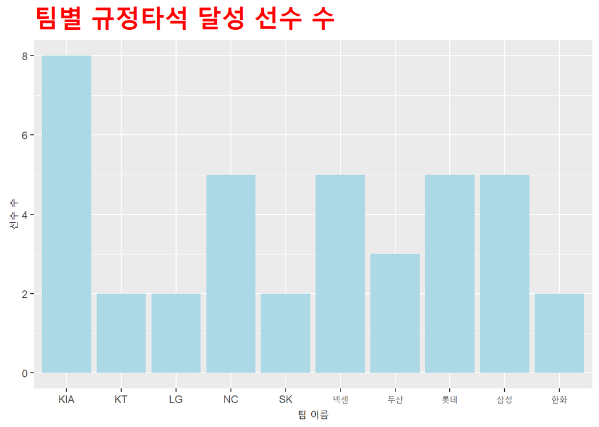

```r
library(ggplot2)

setwd('C:\\Workspace\\WorkspaceR')
base <- read.csv('batter_stats_2017.csv', header = T)

base1 <- base %>% mutate(규정타석=ifelse(타석>=446, 'pass', 'fail') )
base2 <- base1 %>% filter(규정타석=='pass')

ggplot(base2, aes(x=팀명))+
    geom_bar(fill='lightblue')+
    ggtitle('팀별 규정타석 달성 선수 수')+
    theme(plot.title = element_text(size = 24,
                                    face = 'bold',
                                    colour = 'red'))+
    labs(x='팀 이름', y= '선수 수')
```

### 이를 통해 알 수 있 듯 우승팀인 기아의 규정타석 달성 선수는 8명인데 비해, LG의 규정타석 달성 선수는 2명에 불과하다. 이는 확실한 주전이 없어 타팀에 비해 타선의 짜임새가 부족하다고 판단할 수 있다. 하지만 규정타석 달성 선수가 LG와 SK가 2명으로 같고, 두산은 3명으로 1명만 많은데 SK와 두산은 모두 포스트시즌 진출에 성공하였다. 무슨 차이가 있기에 LG만 포스트시즌 진출에 실패한것인가?

## 2. SK,두산과 LG의 비교 ( 경기당 안타, 홈런, 볼넷, 득점, 타율 )

```r
options(max.print = 9999999)
base.sk<- base %>% filter(팀명=='SK')
base.ds <- base %>% filter(팀명=='두산')
base.lg <- base %>% filter(팀명=='LG')

base.sk.ds.lg<- rbind(base.sk,base.ds,base.lg)
```

### 1) 안타 수 비교

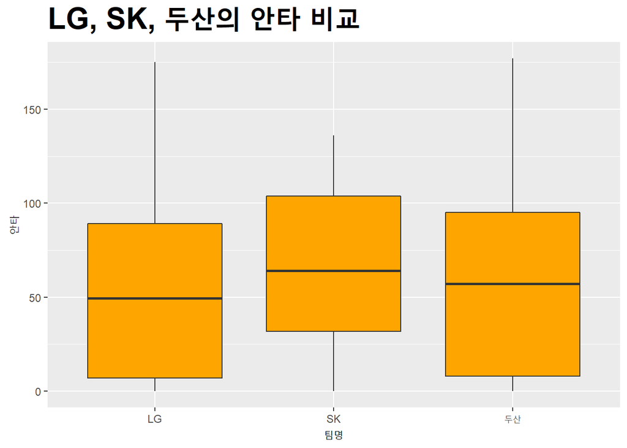

```r
ggplot(base.sk.ds.lg,aes(x=팀명,y=안타))+
    geom_boxplot(fill='orange')+
    ggtitle('LG, SK, 두산의 안타 비교')+
    theme(plot.title = element_text(size = 24,
                                    face='bold'))
```

```r
base.sk %>% select(안타) %>% sum/144           # 경기 당 안타
```

```
## [1] 9.145833
```

```r
base.ds %>% select(안타) %>% sum/144
```

```
## [1] 7.048611
```

```r
base.lg %>% select(안타) %>% sum/144
```

```
## [1] 7.326389
```

### 세 팀 간 안타를 비교해보면 LG와 두산의 수치가 비슷하다. 경기당 안타 측면에서는 오히려 LG가 두산보다 높은 수치를 나타내고 있다.

### 2) 홈런 수 비교

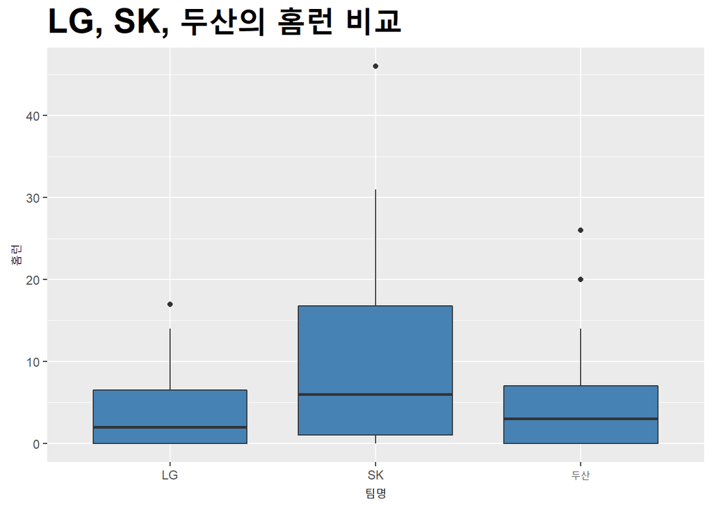

```r
ggplot(base.sk.ds.lg,aes(x=팀명,y=홈런))+
    geom_boxplot(fill='steelblue')+
    ggtitle('LG, SK, 두산의 홈런 비교')+
    theme(plot.title = element_text(size = 24,
                                    face='bold'))
```

```r
base.sk %>% select(홈런) %>% sum/144           # 경기 당 홈런
```

```
## [1] 1.555556
```

```r
base.ds %>% select(홈런) %>% sum/144
```

```
## [1] 0.7083333
```

```r
base.lg %>% select(홈런) %>% sum/144
```

```
## [1] 0.5833333
```

### 세팀의 홈런을 비교해보면 SK가 세 팀 중 가장 높은 수치를 기록하고 있고, LG와 두산은 SK에 비해 낮은 수치를 보이고 있다. LG와 두산을 비교해보면 앞서 경기당 안타는 LG가 많았지만, 경기당 홈런은 두산이 더 많아 적은 안타에도 더 많은 점수를 낼 수 있었다.

### 3) 볼넷 비교

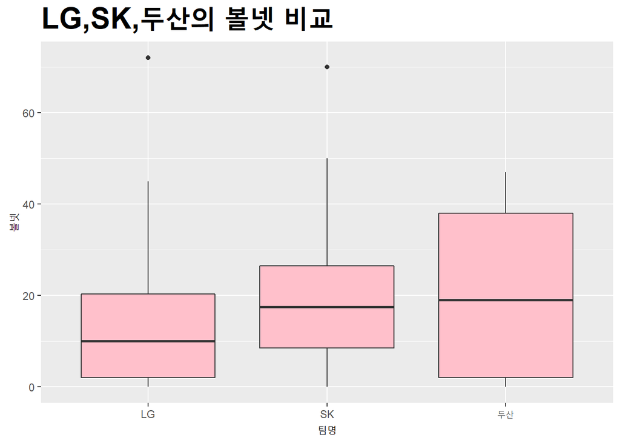

```r
ggplot(base.sk.ds.lg,aes(x=팀명,y=볼넷))+
    geom_boxplot(fill='pink')+
    ggtitle('LG,SK,두산의 볼넷 비교')+
    theme(plot.title = element_text(size = 24,
                                    face='bold'))
```

```r
base.sk %>% select(볼넷) %>%sum/144                  # 경기 당 볼넷
```

```
## [1] 2.923611
```

```r
base.ds %>% select(볼넷) %>%sum/144
```

```
## [1] 2.430556
```

```r
base.lg %>% select(볼넷) %>%sum/144
```

```
## [1] 2.256944
```

### 볼넷 수를 비교해보면 LG 선수들의 평균 볼넷 수가 두 팀에 비해 현저히 낮음을 알 수 있다. 또한 두산은 볼넷을 얻어 낸 타자가 LG와 SK에 비해 비교적 많은 것을 알 수 있다. 이는 두산이 안타가 적어도 출루를 많이 하여 점수를 낼 가능성이 높음을 의미한다.

### 4) 득점 비교

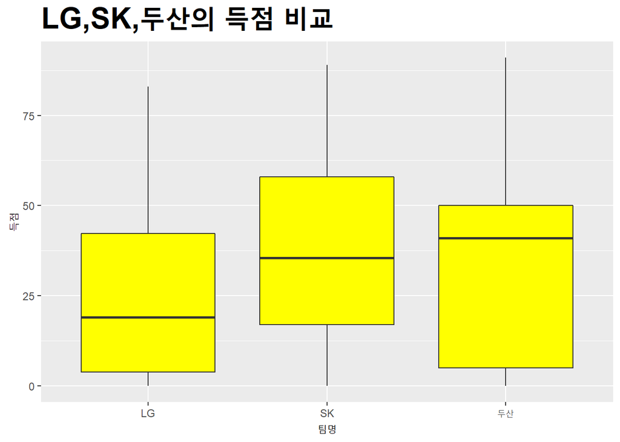

```r
ggplot(base.sk.ds.lg,aes(x=팀명,y=득점))+
    geom_boxplot(fill='yellow')+
    ggtitle('LG,SK,두산의 득점 비교')+
    theme(plot.title = element_text(size = 24,
                                    face='bold'))
```

```r
base.sk.ds.lg %>% filter(팀명=='SK') %>% select(득점) %>% sum/144
```

```
## [1] 5.180556
```

```r
base.sk.ds.lg %>% filter(팀명=='두산') %>% select(득점) %>% sum/144
```

```
## [1] 4.006944
```

```r
base.sk.ds.lg %>% filter(팀명=='LG') %>% select(득점) %>% sum/144
```

```
## [1] 3.645833
```

## 3. 팀 순위별 WAR 합 비교

### WAR이란 대체선수 대비 승리 기여도로 WAR이 6인 선수가 WAR이 0인 선수보다 6승을 더 얻어낸 것으로 보면 된다.

```r
base.kia<- base %>% filter(팀명=='KIA')
base.ds <- base %>% filter(팀명=='두산')
base.lt <- base %>% filter(팀명=='롯데')
base.nc<- base %>% filter(팀명=='NC')
base.sk <- base %>% filter(팀명=='SK')
base.lg <- base %>% filter(팀명=='LG')
base.nx<- base %>% filter(팀명=='넥센')
base.hw <- base %>% filter(팀명=='한화')
base.ss <- base %>% filter(팀명=='삼성')
base.kt <- base %>% filter(팀명=='KT')

war <- c(sum(base.kia$WAR),sum(base.ds$WAR),sum(base.lt$WAR),sum(base.nc$WAR),sum(base.sk$WAR),
         sum(base.lg$WAR),sum(base.nx$WAR),sum(base.hw$WAR),sum(base.ss$WAR),sum(base.kt$WAR))

team <- c(1,2,3,4,5,6,7,8,9,10)
names(team) <- c('KIA','두산','롯데','NC','SK','LG','넥센','한화','삼성','KT')

df.base <- data.frame(team,war)
df.base
```

```
##      team   war
## KIA     1 30.36
## 두산    2 15.91
## 롯데    3 14.85
## NC      4 24.06
## SK      5 17.16
## LG      6  6.80
## 넥센    7 16.23
## 한화    8  9.49
## 삼성    9 11.81
## KT     10  3.98
```

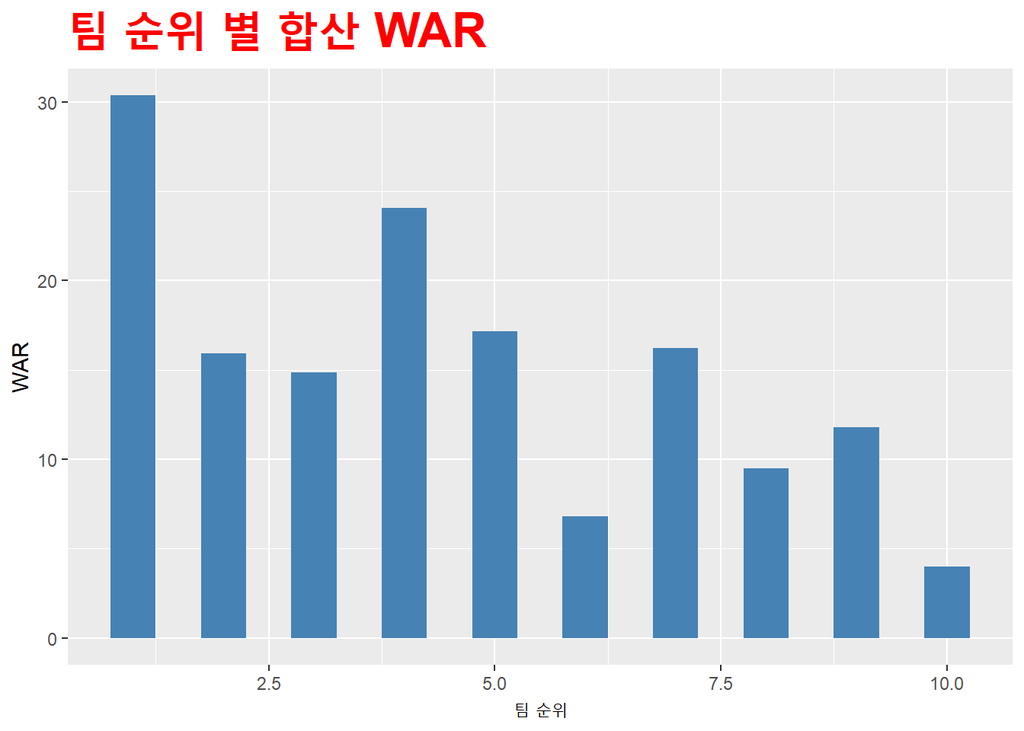

```r
ggplot(df.base,aes(x=team, y=war))+
    geom_bar(stat = 'identity',
             width = 0.5,
             fill='steelblue') +
    ggtitle('팀 순위 별 합산 WAR')+
    theme(plot.title = element_text(size = 24,
                                    face = 'bold',
                                    colour = 'red'))+
    labs(x="팀 순위", y= 'WAR')
```

```r
cor(war,team)   # 등수와 war의 상관계수가 -0.7640916 매우 강한 상관 관계가 있음을 알 수 있다.
```

```
## [1] -0.7640916
```

### 팀별로 각 선수들의 WAR의 합을 비교해본 결과 6위 LG는 신생팀인 10위 KT를 제외하고 최하위에 위치하고 있다. 1위 KIA의 경우 WAR의 합이 30이 넘는데, 이는 KIA 선수들이 대체 선수에 비해 30승을 더 챙겼다는 의미다. 반면 LG 선수들의 WAR 합은 6.8이므로 대체 선수에 비해 6~7승 정도만 더 챙겼음을 의미한다. 이는 LG 선수들이 타 팀 선수들에 비해 승리에 기여하는 정도가 전체적으로 낮다고 할 수 있다.

## 4. 4. 피타고리안 승률과 실제 순위 비교

### 피타고리안 승률이란 득점의 제곱을 득점의 제곱과 실점의 제곱의 합으로 나눈 수로 팀이 얻은 득점과 잃은 실점으로 승률을 예상하는 용도로 쓰인다.

```r
team
```

```
##  KIA 두산 롯데   NC   SK   LG 넥센 한화 삼성   KT
##    1    2    3    4    5    6    7    8    9   10
```

```r
runs.hit <- c(906,849,743,786,761,699,789,737,757,655)
runs.pitch <- c(734,678,701,745,767,677,764,820,911,876)



runs<- data.frame(team,runs.hit,runs.pitch)
runs
```

```
##      team runs.hit runs.pitch
## KIA     1      906        734
## 두산    2      849        678
## 롯데    3      743        701
## NC      4      786        745
## SK      5      761        767
## LG      6      699        677
## 넥센    7      789        764
## 한화    8      737        820
## 삼성    9      757        911
## KT     10      655        876
```

```r
runs1<- runs %>% mutate(피타고리안_승률=runs.hit^2/(runs.hit^2+runs.pitch^2))
runs1
```

```
##    team runs.hit runs.pitch 피타고리안_승률
## 1     1      906        734       0.6037370
## 2     2      849        678       0.6105973
## 3     3      743        701       0.5290613
## 4     4      786        745       0.5267607
## 5     5      761        767       0.4960734
## 6     6      699        677       0.5159843
## 7     7      789        764       0.5160937
## 8     8      737        820       0.4468434
## 9     9      757        911       0.4084542
## 10   10      655        876       0.3585963
```

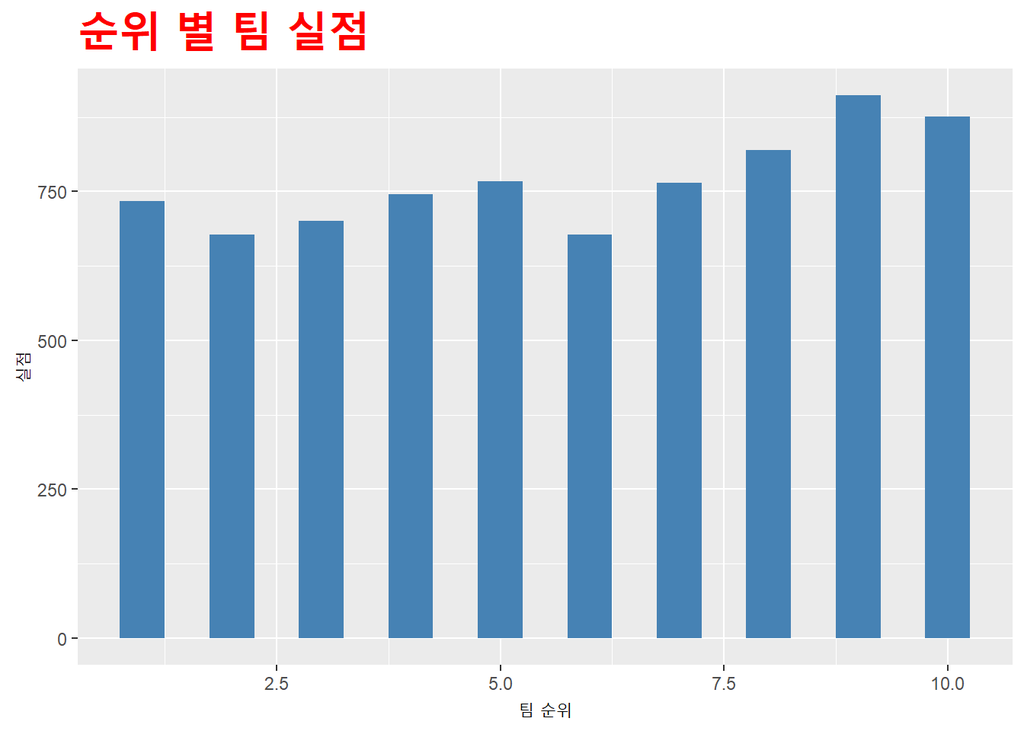

```r
ggplot(runs1,aes(x=team,y=runs.pitch))+
    geom_bar(stat = 'identity',
             width = 0.5,
             fill='steelblue')+
    ggtitle('순위 별 팀 실점')+
    theme(plot.title = element_text(size = 24,
                                    face = 'bold',
                                    colour = 'red'))+
    labs(x='팀 순위', y='실점')
```

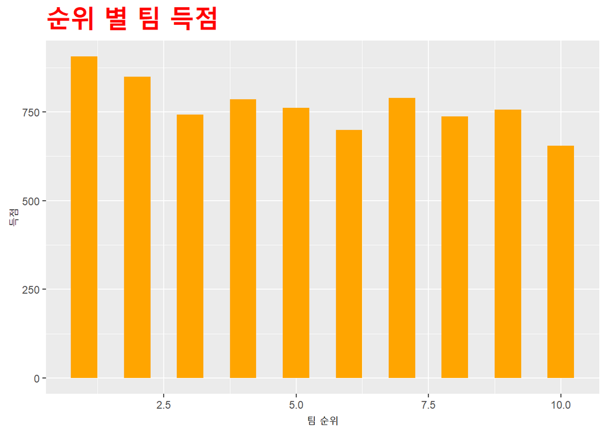

```r
ggplot(runs1,aes(x=team,y=runs.hit))+
    geom_bar(stat = 'identity',
             width = 0.5,
             fill='orange')+
    ggtitle('순위 별 팀 득점')+
    theme(plot.title = element_text(size = 24,
                                    face = 'bold',
                                    colour = 'red'))+
    labs(x='팀 순위', y='득점')
```

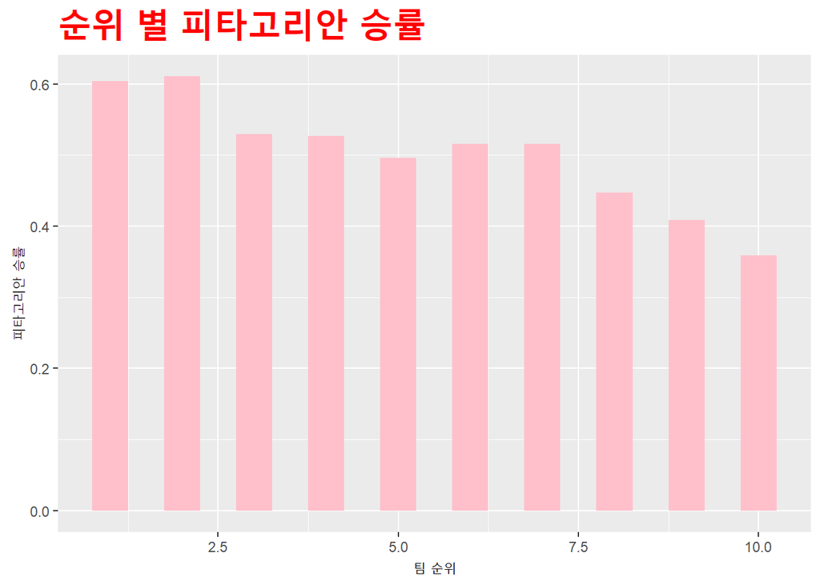

```r
ggplot(runs1,aes(x=team,y=피타고리안_승률))+
    geom_bar(stat = 'identity',
             width = 0.5,
             fill='pink')+
    ggtitle('순위 별 피타고리안 승률')+
    theme(plot.title = element_text(size = 24,
                                    face = 'bold',
                                    colour = 'red'))+
    labs(x='팀 순위', y='피타고리안 승률')
```

```r
library(corrplot)
cor(runs1)
```

```
##                       team   runs.hit runs.pitch 피타고리안_승률
## team             1.0000000 -0.7692824  0.7976307      -0.9385627
## runs.hit        -0.7692824  1.0000000 -0.3889146       0.8073831
## runs.pitch       0.7976307 -0.3889146  1.0000000      -0.8566162
## 피타고리안_승률 -0.9385627  0.8073831 -0.8566162       1.0000000
```

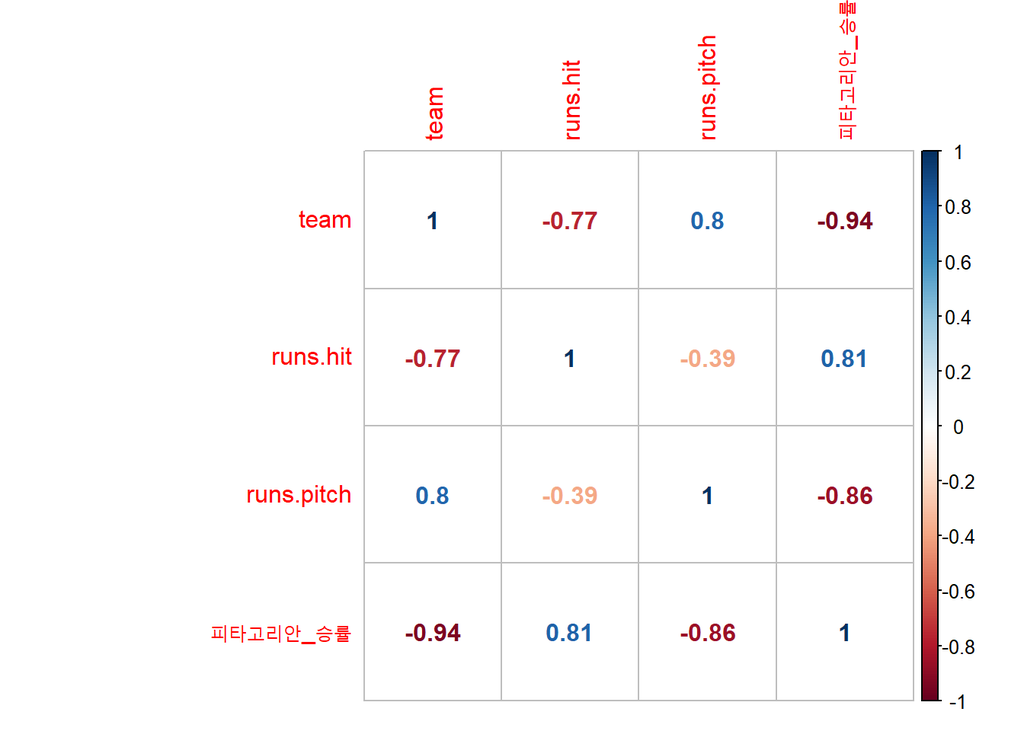

```r
corrplot(cor(runs1),method = "number")
```